# Zombie HW

Laura Brubaker-Wittman

10/8/2019

## Homework Set-up:

*Load in the dataset “zombies.csv” from my GitHub repo at https://github.com/fuzzyatelin/fuzzyatelin.github.io/tree/master/AN597_Fall19/. This data includes the first and last name and gender of the entire population of 1000 people who have survived the zombie apocalypse and are now ekeing out an existence somewhere on the East Coast, along with several other variables (height, weight, age, number of years of education, number of zombies they have killed, and college major).*

In order to do this, I will run the code below, after loading the {curl} library:

```r
library(curl)
f <- f <- curl("https://raw.githubusercontent.com/fuzzyatelin/fuzzyatelin.github.io/master/AN597_Fall19/zombies.csv")
d <- read.csv(f, header = TRUE, sep = ",", stringsAsFactors = FALSE)
head(d)
```

```
##   id first_name last_name gender   height   weight zombies_killed
## 1  1      Sarah    Little Female 62.88951 132.0872              2
## 2  2       Mark    Duncan   Male 67.80277 146.3753              5
## 3  3    Brandon     Perez   Male 72.12908 152.9370              1
## 4  4      Roger   Coleman   Male 66.78484 129.7418              5
## 5  5      Tammy    Powell Female 64.71832 132.4265              4
## 6  6    Anthony     Green   Male 71.24326 152.5246              1
##   years_of_education                           major      age
## 1                  1                medicine/nursing 17.64275
## 2                  3 criminal justice administration 22.58951
## 3                  1                       education 21.91276
## 4                  6                  energy studies 18.19058
## 5                  3                       logistics 21.10399
## 6                  4                  energy studies 21.48355
```

This shows me the first 6 rows of the data and my ‘Global Environment’ in R Studio also shows that this data is now loaded for this work session.

## Homework Questions:

1. *Calculate the population mean and standard deviation for each quantitative random variable (height, weight, age, number of zombies killed, and years of education). NOTE: You will not want to use the built in var() and sd() commands as these are for samples.*

**Height:**

First, I want to make a vector that only includes all of the heights. To do so, I will use the code below:

```r
h <- c(d$height)
head(h)
```

```
## [1] 62.88951 67.80277 72.12908 66.78484 64.71832 71.24326
```

Looks like this worked! The first six elements it gave back match the first six from the "height’ column in our original table.

Next, I will find the mean of this vector, using the mean() function built in to R:

```r
h_mean <- mean(h)
h_mean
```

```
## [1] 67.6301
```

This answer also makes sense, looking briefly over the overall data.

Next, we will find the population standard deviation for height. For this, we will use the sd() function in R, to find the sample standard deviation first:

```r
h_sd <- sd(h)
h_sd
```

```
## [1] 4.310126
```

Now, to find the population standard deviation, we will take this result and multiply it by the square root of (N-1)/N in which N is the number of values for height:

```r
h_psd <- function(h){h_sd*sqrt((length(h)-1)/length(h))}
h_psd(h)
```

```
## [1] 4.30797
```

As we can see, this is close to the number we got back when using sd() only, but this is now more accurate to describe the standard deviation for the entire population instead of just a sample from the population.

We can next do this for each of the other quantitative random variables:

**Weight:**

First, we make a vector from just the ‘weight’ column from the original data frame:

```r
w <- c(d$weight)
head(w)
```

```
## [1] 132.0872 146.3753 152.9370 129.7418 132.4265 152.5246
```

Next, we find the mean:

```r
w_mean <- mean(w)
w_mean
```

```
## [1] 143.9075
```

This answer looks good! Next up, is sample standard deviation so we can find population standard deviation:

```r
w_sd <- sd(w)
w_sd
```

```
## [1] 18.40106
```

Ok, now we can put this into the population standard deviation function:

```r
w_psd <- function(w){w_sd*sqrt((length(w)-1)/length(w))}
w_psd(w)
```

```
## [1] 18.39186
```

Great, let’s keep going with the other variables!

**Age:**

First, we make a vector from just the ‘age’ column from the original data frame:

```r
a <- c(d$age)
head(a)
```

```
## [1] 17.64275 22.58951 21.91276 18.19058 21.10399 21.48355
```

Next, we find the mean:

```r
a_mean <- mean(a)
a_mean
```

```
## [1] 20.04696
```

Next up, is sample standard deviation so we can find population standard deviation:

```r
a_sd <- sd(a)
a_sd
```

```
## [1] 2.965066
```

Ok, now we can put this into the population standard deviation function:

```r
a_psd <- function(a){a_sd*sqrt((length(a)-1)/length(a))}
a_psd(a)
```

```
## [1] 2.963583
```

Looking good! Next up is ‘number of zombies killed.’ Fun!!

**Number of Zombies Killed:**

First, we make a vector from just the ‘Zombies_killed’ column from the original data frame:

```r
k <- c(d$zombies_killed)
head(k)
```

```
## [1] 2 5 1 5 4 1
```

Next, we find the mean:

```r
k_mean <- mean(k)
k_mean
```

```
## [1] 2.992
```

Looks like on average they haven’t had to kill TOO many zombies…yet!

Next up, is sample standard deviation so we can find population standard deviation:

```r
k_sd <- sd(k)
k_sd
```

```
## [1] 1.748426
```

Ok, now we can put this into the population standard deviation function:

```r
k_psd <- function(k){k_sd*sqrt((length(k)-1)/length(k))}
k_psd(k)
```

```
## [1] 1.747551
```

Awesome! Almost there. The last variable we will get the mean and population standard deviation for is ‘years of education.’

**Years of Education:**

First, we make a vector from just the ‘year_of_education’ column from the original data frame:

```r
e <- c(d$years_of_education)
head(e)
```

```
## [1] 1 3 1 6 3 4
```

Next, we find the mean:

```r
e_mean <- mean(e)
e_mean
```

```
## [1] 2.996
```

Most definitely a college town!

Next up, is sample standard deviation so we can find population standard deviation:

```r
e_sd <- sd(e)
e_sd
```

```
## [1] 1.676543
```

Ok, now we can put this into the population standard deviation function:

```r
e_psd <- function(e){e_sd*sqrt((length(e)-1)/length(e))}
e_psd(e)
```

```
## [1] 1.675704
```

Great! Now we have all of our population means and standard deviations for this variables, we can move on to question #2!

2. *Use {ggplot} to make boxplots of each of these variables by gender.*

First off, this is an interesting population in which every person identifies as either male or female. While I am not one for people having to identify by a strict gender binary, we will go with it for this exercise.

As far as coding, at first, I think I made this way too hard, thinking I would need to write functions into the {ggplot} function. But, then I realized that this is part of the awesomeness of {ggplot}, that it has built-in functions already and knows what to do with the data when you ask it to create a boxplot based on specific variables. After looking through older modules, this is what I came up with:

**Height**

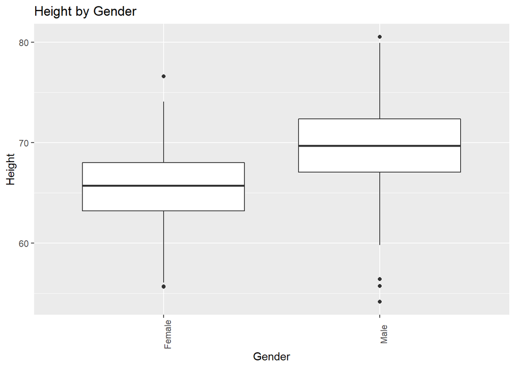

```r
library(ggplot2)
height_gender <- ggplot(data=d, aes(x=gender, y=height)) #this means I am pulling from the data frame "d" and that the variables for my x axis will be pulled from the column marked "gender" and grouped by each category found, in this case, male and female, and that my y axis variables will be pulled from the column marked "height"
height_gender <- height_gender + geom_boxplot() #this tells R that we specifically want a boxplot
height_gender <- height_gender + theme(axis.text.x=element_text(angle=90)) #each element of the X axis will be at a 90 degree angle.
height_gender <- height_gender + ylab("Height") #this means the y axis will be labeled "Height"
height_gender <- height_gender + xlab("Gender") #this means the x axis will be labeled "Gender"
height_gender <- height_gender + ggtitle("Height by Gender") #this means the label at the top of plot will be "Height by Gender"
height_gender
```

This looks pretty good! Not sure why the title is not centered, but all the elements are there. Also, probably do not need to have “Female” and “Male” at a 90 degree angle, but it is cool to know how to do this for making a box plot that has a large number of x axis variables.

Now we can do the same for the other variables:

**Age**

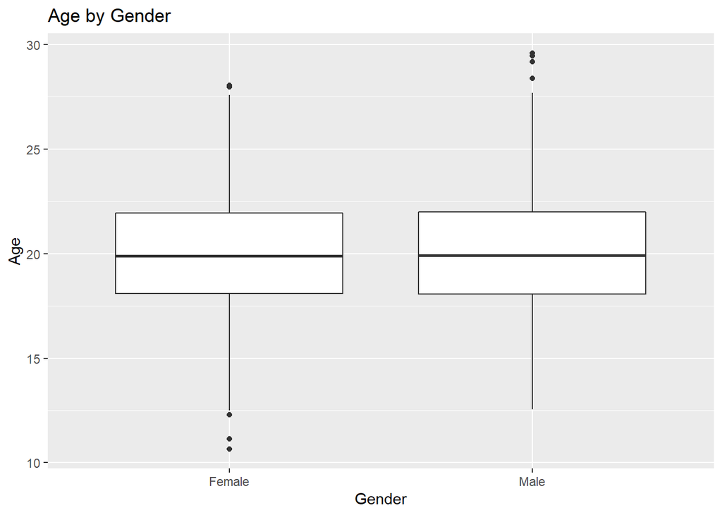

```r
age_gender <- ggplot(data=d, aes(x=gender, y=age))
age_gender <- age_gender + geom_boxplot()
age_gender <- age_gender + ylab("Age")
age_gender <- age_gender + xlab("Gender")
age_gender <- age_gender + ggtitle("Age by Gender")
age_gender
```

This shows us that the ages of both males and females are the really close for this zombie killing population!

Also, I took out the line of code for angling the x-axis labels and it looks good. They can stay horizontal like this when we only have two groups we are comparing.

Next up weight (yes, I realize I did age and weight out of order. Oh well!):

**Weight**

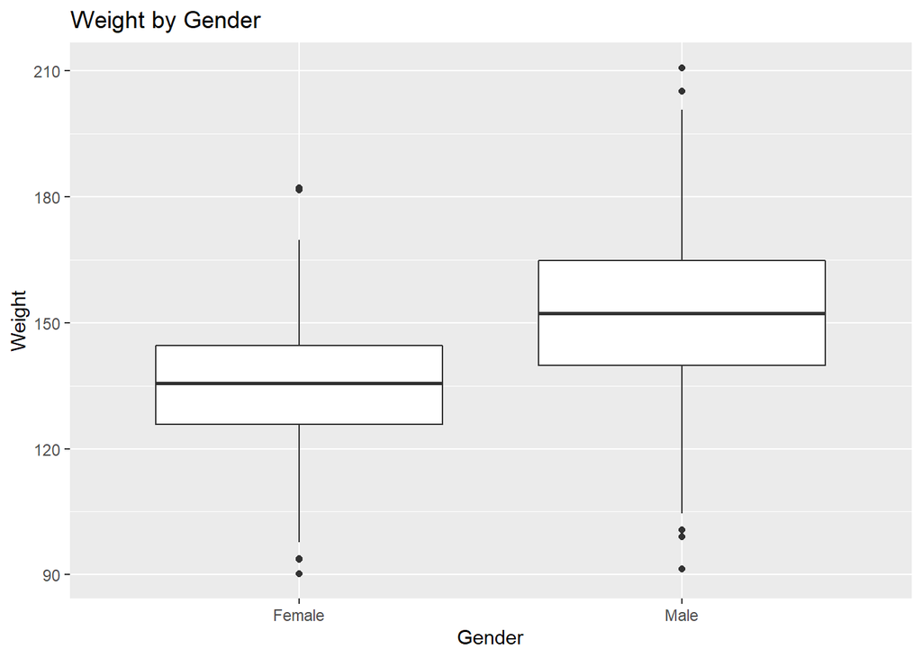

```r
weight_gender <- ggplot(data=d, aes(x=gender, y=weight))
weight_gender <- weight_gender + geom_boxplot()
weight_gender <- weight_gender + ylab("Weight")
weight_gender <- weight_gender + xlab("Gender")
weight_gender <- weight_gender + ggtitle("Weight by Gender")
weight_gender
```

Looks good! Males overall weigh more than females, which makes sense.

**Number of Zombies Killed**

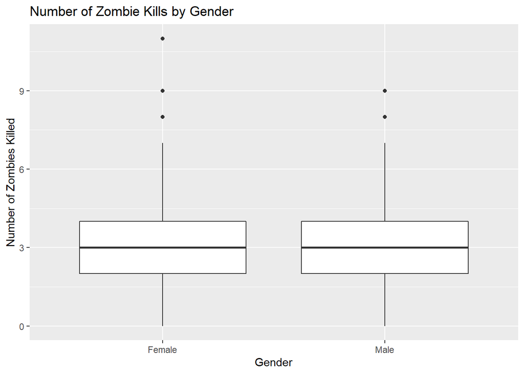

```r
kills_gender <- ggplot(data=d, aes(x=gender, y=zombies_killed))
kills_gender <- kills_gender + geom_boxplot()
kills_gender <- kills_gender + ylab("Number of Zombies Killed")
kills_gender <- kills_gender + xlab("Gender")
kills_gender <- kills_gender + ggtitle("Number of Zombie Kills by Gender")
kills_gender
```

Looks like zombie kills are not differentiate by gender, with some of the highest kills being by females.

**Years of Education**

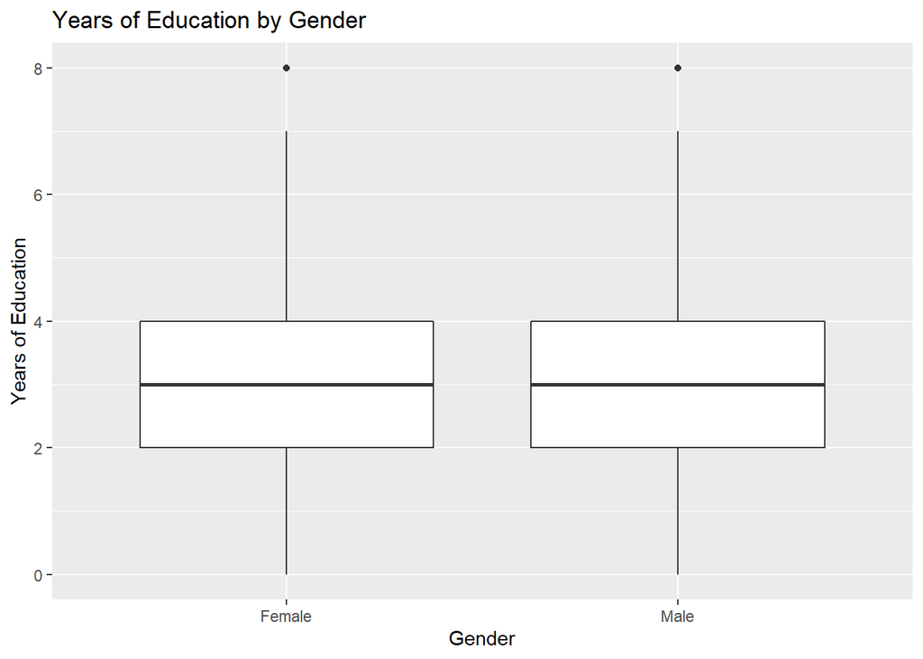

```r
edu_gender <- ggplot(data=d, aes(x=gender, y=years_of_education))
edu_gender <- edu_gender + geom_boxplot()
edu_gender <- edu_gender + ylab("Years of Education")
edu_gender <- edu_gender + xlab("Gender")
edu_gender <- edu_gender + ggtitle("Years of Education by Gender")
edu_gender
```

Looks good! On to question #3.

3. *Use {ggplot} to make scatterplots of height and weight in relation to age. Do these variables seem to be related? In what way?*

Here is the scatterplot for **Height in Relation to Age:**

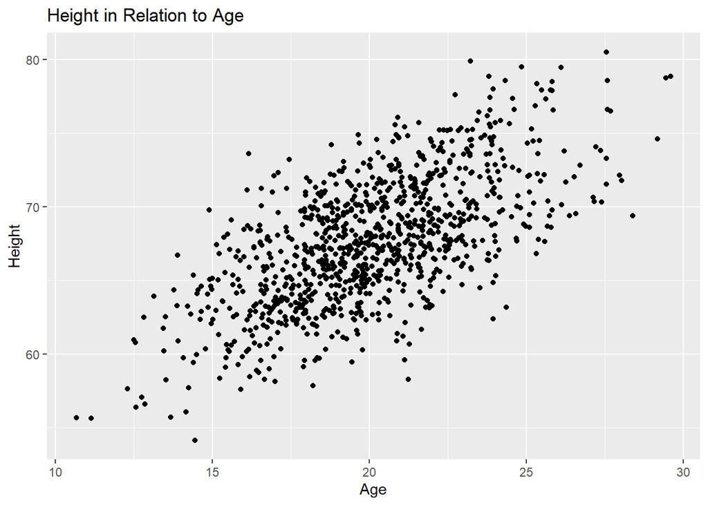

```r
height_age <- ggplot(data = d, aes(x = age, y = height))
height_age <- height_age + xlab("Age") + ylab("Height")
height_age <- height_age + geom_point()
height_age <- height_age + ggtitle("Height in Relation to Age")
height_age
```

There seems to be a general positive correlation between height and age, in that, as one gets older, the tend to get taller, with the assumption that this would plateau at a certain point.

Here is the scatterplot for **Weight in Relation to Age:**

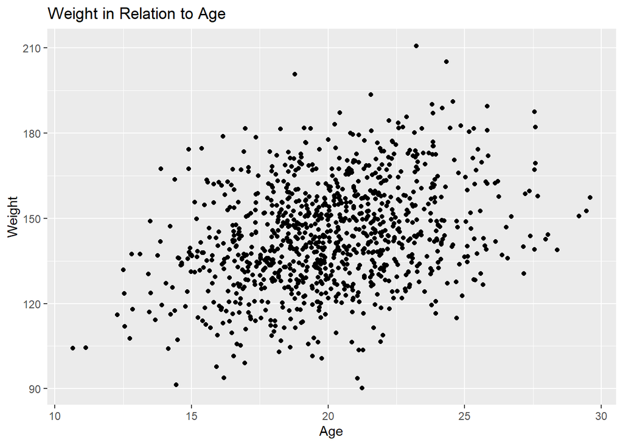

```r
weight_age <- ggplot(data = d, aes(x = age, y = weight))
weight_age <- weight_age + xlab("Age") + ylab("Weight")
weight_age <- weight_age + geom_point()
weight_age <- weight_age + ggtitle("Weight in Relation to Age")
weight_age
```

While this one also appears to have an overall positive correlation, in that as one gets older, they tend to weigh more, it seems a bit weaker than the relationship between height and age.

4. *Using histograms and Q-Q plots, check whether the quantitative variables seem to be drawn from a normal distribution. Which seem to be and which do not (hint: not all are drawn from the normal distribution)? For those that are not normal, can you determine from which common distribution they are drawn?*

Here is the Q-Q plot for Height:

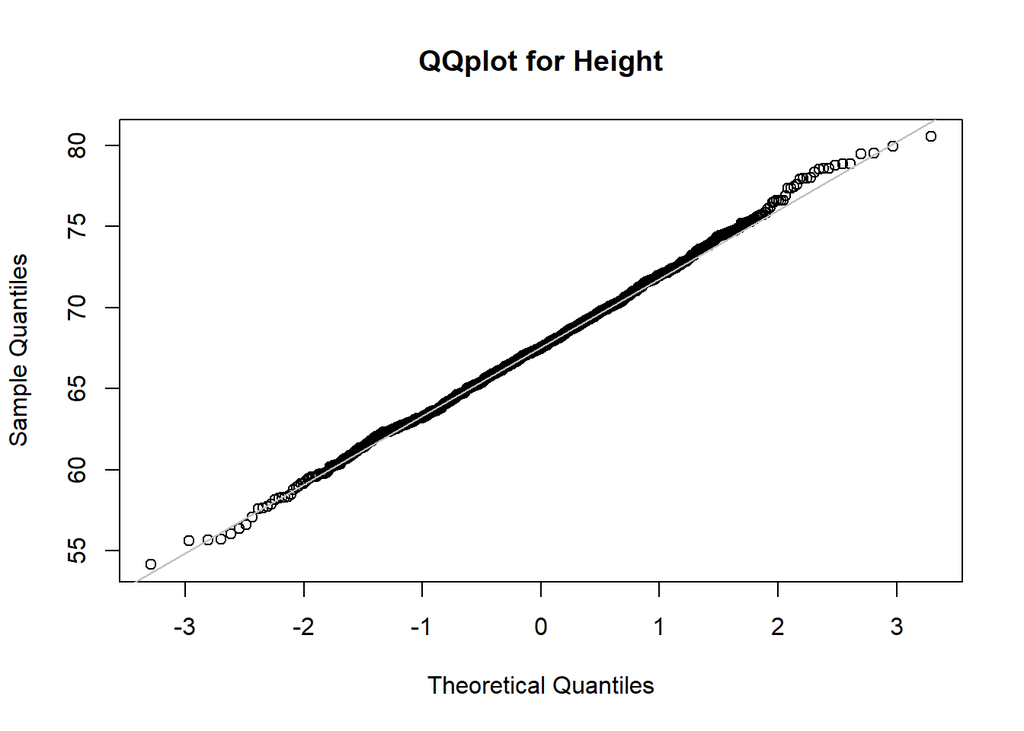

```r
qqnorm(h, main= "QQplot for Height")
qqline(h, col = "gray") #Makes a Q-Q line to see how the points fall on this line, and the color of the line is gray
```

Here is a historgram for Height:

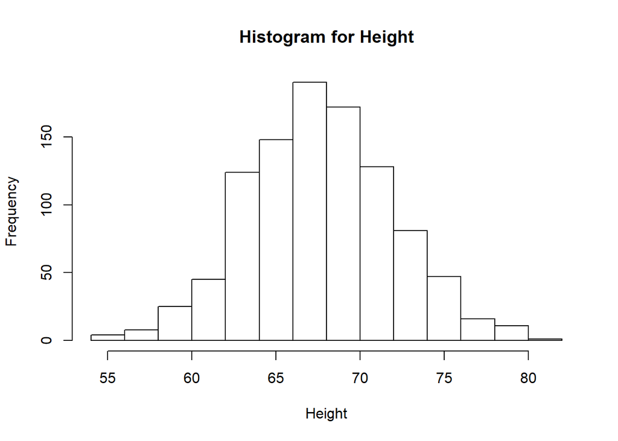

```r
hist(h, main = "Histogram for Height", xlab = "Height") #code for a histogram along with the main title of the graph and the x-axis label
```

Based on both of these, it looks like height is normally distributed.

Here is the QQplot for Weight:

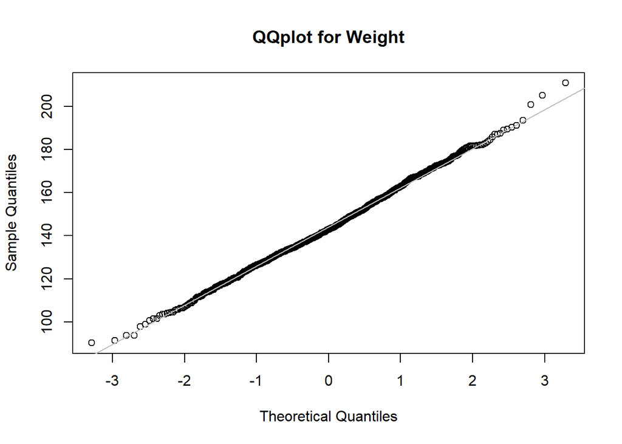

```r
qqnorm(w, main= "QQplot for Weight")
qqline(w, col = "gray")
```

Historgram for Weight:

[figure not shown]

```r
hist(h, main = "Histogram for Weight", xlab = "Weight")
```

Weight also looks normally distributed, which makes sense for this population.

QQplot for Age:

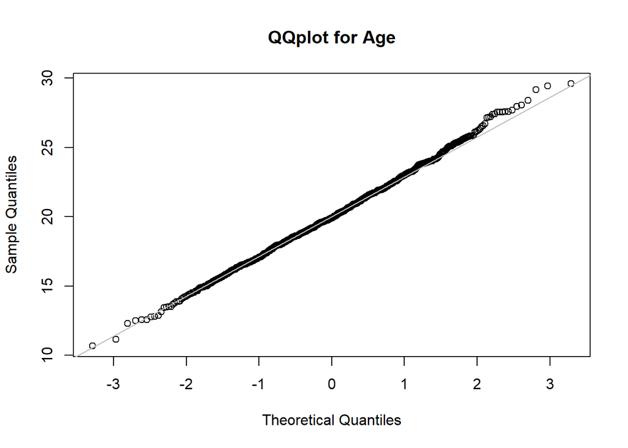

```r
qqnorm(a, main= "QQplot for Age")
qqline(a, col = "gray")
```

Here is the histogram for Age:

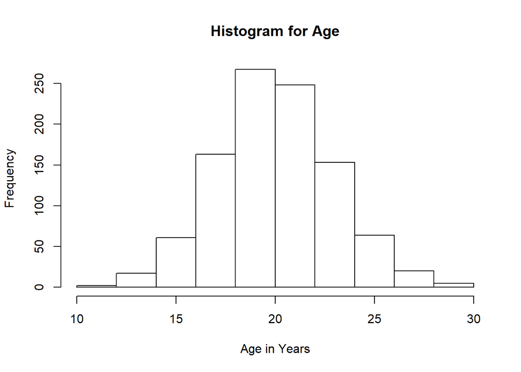

```r
hist(a, main = "Histogram for Age", xlab = "Age in Years")
```

Overall, age seems to be normally distributed, though not quite as standardized as height and weight.

Here is the QQplot for Number of Zombies Killed:

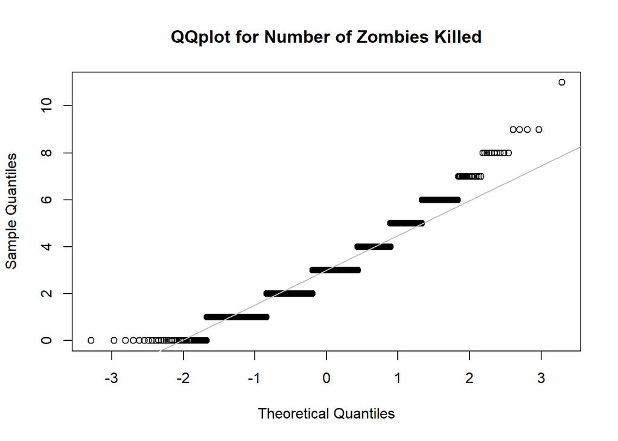

```r
qqnorm(k, main= "QQplot for Number of Zombies Killed")
qqline(k, col = "gray")
```

Here is the histogram for **Number of Zombies Killed:**

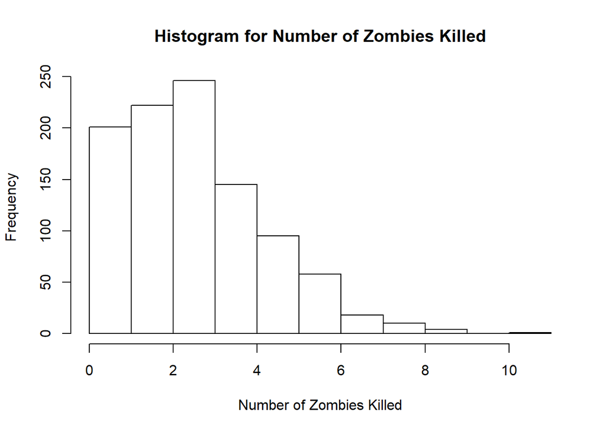

```r
hist(k, main = "Histogram for Number of Zombies Killed", xlab = "Number of Zombies Killed")
```

Here is the QQ plot for **Years of Education:**

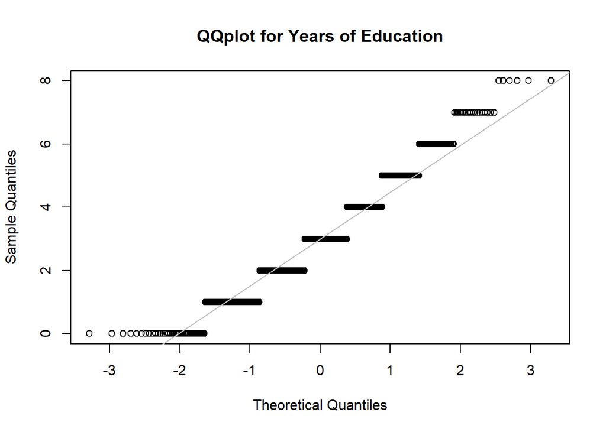

```r
qqnorm(e, main= "QQplot for Years of Education")
qqline(e, col = "gray")
```

And here is the histogram:

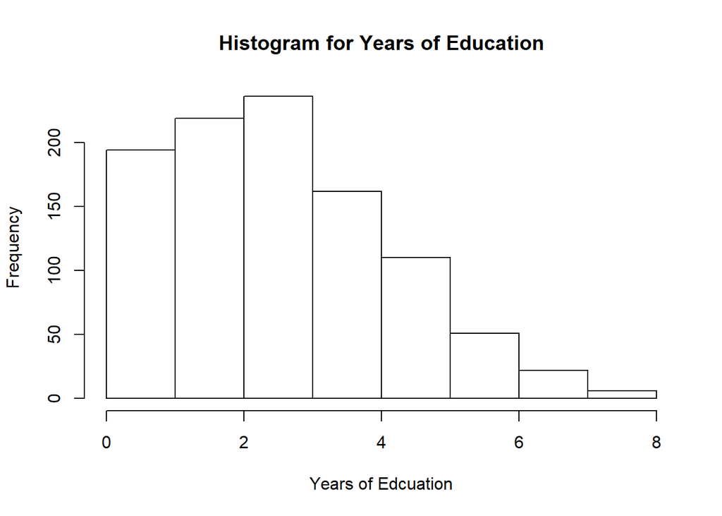

```r
hist(e, main = "Histogram for Years of Education", xlab = "Years of Edcuation")
```

This one follows a similar pattern to number of zombies killed, with a one end of the data skewed instead of having a central tendency, or “Right Skewed.”

5. *Now use the sample() function to sample ONE subset of 30 zombie survivors (without replacement) from this population and calculate the mean and sample standard deviation for each variable. Also estimate the standard error for each variable, and construct the 95% confidence interval for each mean. Note that for the variables that are not drawn from the normal distribution, you may need to base your estimate of the CIs on slightly different code than for the normal.*

Ok, let’s try this for our first variable, which is **Height:**

First, we will take a sample of 30 random heights from our population of heights:

```r
h_sample <- sample(h, size = 30)
h_sample
```

```
##  [1] 66.27632 70.11203 67.70104 69.68828 68.61862 70.76268 67.89872
##  [8] 68.09101 66.14164 65.21957 67.42625 67.29899 67.60750 65.88747
## [15] 63.39950 70.26668 76.60479 69.74712 66.35267 61.02291 71.01244
## [22] 63.68960 69.35963 70.09881 71.94457 68.74930 59.14821 63.65600
## [29] 60.95832 63.27806
```

Great! Now let’s find the mean and standard deviation for this sample:

```r
h_sample_mean <- mean(h_sample)
h_sample_mean
```

```
## [1] 67.26729
```

```r
h_sample_sd <- sd(h_sample) # We can use just the sd() function this time since this is a sample standard deviation and not a population standard deviation
h_sample_sd
```

```
## [1] 3.680551
```

Here is the standard error:

```r
library(sciplot)
h_sample_se <- se(h_sample)
h_sample_se
```

```
## [1] 0.6719737
```

For the confidence intervals, we will do:

```r
upper_h <- h_sample_mean + qnorm(0.975) * h_sample_se
lower_h <- h_sample_mean + qnorm(0.025) * h_sample_se
h_sample_ci <- (c(lower_h, upper_h))
h_sample_ci
```

```
## [1] 65.95025 68.58434
```

Awesome! Now let’s do the same for the other variables.

Next up is **Weight:**

```r
w_sample <- sample(w, size = 30)
w_sample
```

```
##  [1] 139.5136 181.8052 128.8427 132.3134 156.8429 121.8163 162.3697
##  [8] 145.1882 136.7951 146.3753 133.8279 137.0027 156.2692 163.0375
## [15] 141.5698 167.3073 119.9920 165.0062 152.0467 148.3196 144.9560
## [22] 128.3759 187.4691 172.0703 167.6969 161.8009 143.4554 139.1095
## [29] 173.4268 165.4885
```

```r
w_sample_mean <- mean(w_sample)
w_sample_mean
```

```
## [1] 150.6697
```

```r
w_sample_sd <- sd(w_sample)
w_sample_sd
```

```
## [1] 17.61959
```

```r
w_sample_se <- se(w_sample)
w_sample_se
```

```
## [1] 3.216882
```

```r
upper_w <- w_sample_mean + qnorm(0.975) * w_sample_se
lower_w <- w_sample_mean + qnorm(0.025) * w_sample_se
w_sample_ci <- (c(lower_w, upper_w))
w_sample_ci
```

```
## [1] 144.3647 156.9747
```

Looks good! Now we can do the same for Age, since it is also a normally distributed random variable:

```r
a_sample <- sample(a, size = 30)
a_sample
```

```
##  [1] 16.16114 18.80625 18.98611 18.31888 17.90379 19.38432 16.98715
##  [8] 16.02056 19.09397 23.30563 21.65099 23.89309 23.27623 18.13684
## [15] 21.46295 22.52837 22.21023 16.64580 21.42912 17.93957 21.22370
## [22] 19.30345 18.12094 25.17245 16.46003 24.46873 22.71537 23.61626
## [29] 16.53939 26.37661
```

```r
a_sample_mean <- mean(a_sample)
a_sample_mean
```

```
## [1] 20.27126
```

```r
a_sample_sd <- sd(a_sample)
a_sample_sd
```

```
## [1] 2.995069
```

```r
a_sample_se <- se(a_sample)
a_sample_se
```

```
## [1] 0.5468222
```

```r
upper_a <- a_sample_mean + qnorm(0.975) * a_sample_se
lower_a <- a_sample_mean + qnorm(0.025) * a_sample_se
a_sample_ci <- (c(lower_a, upper_a))
a_sample_ci
```

```
## [1] 19.19951 21.34302
```

Now we can move on to our two variables that are not normally distributed. We will do the same process for everything but the confidence intervals, which we will bootstrap. I think this should work!

Let’s look at **Number of Zombies Killed:**

```r
k_sample <- sample(k, size = 30)
k_sample
```

```
##  [1] 2 3 4 2 1 2 5 6 3 3 3 2 3 3 0 0 0 6 3 3 4 3 1 3 7 5 3 0 3 1
```

```r
k_sample_mean <- mean(k_sample)
k_sample_mean
```

```
## [1] 2.8
```

```r
k_sample_sd <- sd(k_sample)
k_sample_sd
```

```
## [1] 1.808028
```

```r
k_sample_se <- se(k_sample)
k_sample_se
```

```
## [1] 0.3300993
```

Ok, now let’s try bootstrapping for the CIs:

```r
set <- NULL
n <- 30
for (i in 1:1000){
    set[i] <- mean(sample(k, n, replace=TRUE))
}
quantile(set, c(0.025, 0.975))
```

```
##     2.5%    97.5%
## 2.399167 3.633333
```

These answers seem to make sense from what we know about the patterns we have already seen for the Number of Zombies Killed variable.

Now we can do the same for **Year of Education:**

```r
e_sample <- sample(e, size = 30)
e_sample
```

```
##  [1] 2 8 3 4 5 3 3 3 5 1 1 5 5 5 2 1 0 3 3 2 0 1 2 4 7 2 2 4 3 1
```

```r
e_sample_mean <- mean(e_sample)
e_sample_mean
```

```
## [1] 3
```

```r
e_sample_sd <- sd(e_sample)
e_sample_sd
```

```
## [1] 1.929803
```

```r
e_sample_se <- se(e_sample)
e_sample_se
```

```
## [1] 0.3523321
```

And now we will try bootstrapping again for the CIs:

```r
set <- NULL
n <- 30
for (i in 1:1000){
    set[i] <- mean(sample(e, n, replace=TRUE))
}
quantile(set, c(0.025, 0.975))
```

```
##     2.5%    97.5%
## 2.432500 3.634167
```

I guess this makes sense too, but the numbers are really similar to what we got for Numbers of Zombies Killed. Not sure if this is right? And also unsure if I should have somehow adjusted the code to reflect the numbers from just sample I pulled? The way I have it set up now, it is pulling from the entire population. I might play around with it some more before turning in.

6. Now draw 99 more random samples of 30 zombie apocalypse survivors, and calculate the mean for each variable for each of these samples. Together with the first sample you drew, you now have a set of 100 means for each variable (each based on 30 observations), which constitutes a sampling distribution for each variable. What are the means and standard deviations of this distribution of means for each variable? How do the standard deviations of means compare to the standard errors estimated in [5]? What do these sampling distributions look like (a graph might help here)? Are they normally distributed? What about for those variables that you concluded were not originally drawn from a normal distribution?

Ok, looks like we learned how to do this in **Module 8.** Let’s try it for **Height:**

```r
h_sample_dis <- NULL
for (i in 1:99){
    h_sample_dis[[i]] <- sample(h,size=30, replace=FALSE)
}
head(h_sample_dis)
```

```
## [[1]]
##  [1] 65.32725 66.90534 66.63451 68.75039 76.44105 67.29623 73.70542
##  [8] 73.02198 74.87625 68.65733 63.32658 67.68777 65.36311 66.95557
## [15] 67.64617 63.08010 66.23402 75.27081 66.02102 72.69807 62.79975
## [22] 75.45580 67.77419 69.19429 67.17895 68.13148 68.33511 68.30398
## [29] 64.19751 72.51684
##
## [[2]]
##  [1] 78.86801 68.60438 68.71798 60.87037 73.02337 63.65083 61.45906
##  [8] 68.86074 69.04027 63.53249 61.72987 63.19721 63.10196 72.42676
## [15] 65.94479 71.49300 73.70542 67.97952 69.16849 64.79635 67.06533
## [22] 64.08300 69.42668 73.23254 71.79126 65.89614 68.39926 61.37148
## [29] 71.58885 68.63621
##
## [[3]]
```

[output cut: 26 more lines]

Ok, now we have a sampling distribution. From this, let’s find the mean and standard deviation:

```r
hsdm <- NULL
for (i in 1:99){
    hsdm[i] <- mean(h_sample_dis[[i]])
}
mean(hsdm)
```

```
## [1] 67.47296
```

```r
sd(hsdm)
```

```
## [1] 0.7409342
```

Great! This looks good. Let’s try a graph too:

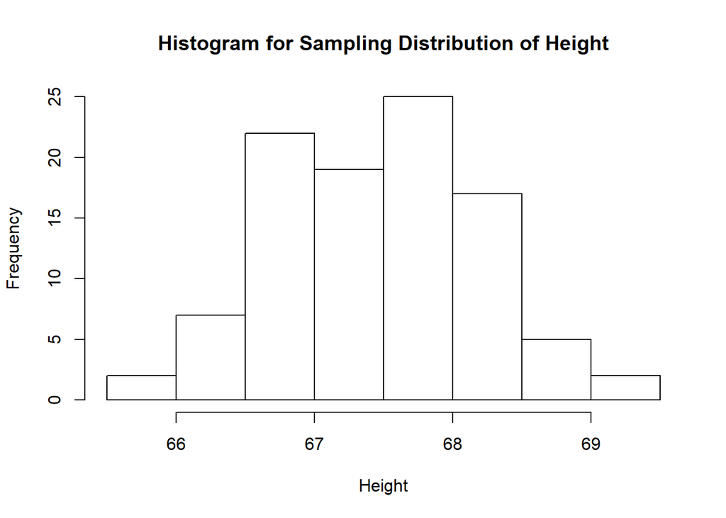

```r
hist(hsdm, main = "Histogram for Sampling Distribution of Height", xlab = "Height")
```

Seems to be normally distributed.

Ok, now let’s do this for all the other variables.

**Weight:**

```r
w_sample_dis <- NULL
for (i in 1:99){
    w_sample_dis[[i]] <- sample(w,size=30, replace=FALSE)
}
head(w_sample_dis)
```

```
## [[1]]
##  [1] 137.5064 121.7732 125.8349 117.5206 161.1474 148.5910 136.6428
##  [8] 173.4268 149.1776 147.1745 140.2764 127.7218 144.8788 111.5025
## [15] 135.8560 179.3823 136.7623 114.8988 141.7615 136.9853 131.4980
## [22] 121.8496 126.5542 145.7219 131.6908 103.6431 174.6625 134.3390
## [29] 149.9791 149.5637
##
## [[2]]
##  [1] 167.5290 128.2554 136.4794 140.6522 153.2824 147.1452 127.5714
##  [8] 151.6471 143.7311 145.4172 138.2881 146.1663 126.5743 167.3073
## [15] 165.5350 139.8103 137.5178 155.6125 150.5904 120.2287 150.7273
## [22] 131.3038 159.6138 168.9203 134.0057 159.3356 168.6675 157.3328
## [29] 141.6000 157.6102
##
## [[3]]
```

[output cut: 26 more lines]

```r
wsdm <- NULL
for (i in 1:99){
    wsdm[i] <- mean(w_sample_dis[[i]])
}
mean(wsdm)
```

```
## [1] 143.8029
```

```r
sd(wsdm)
```

```
## [1] 2.98631
```

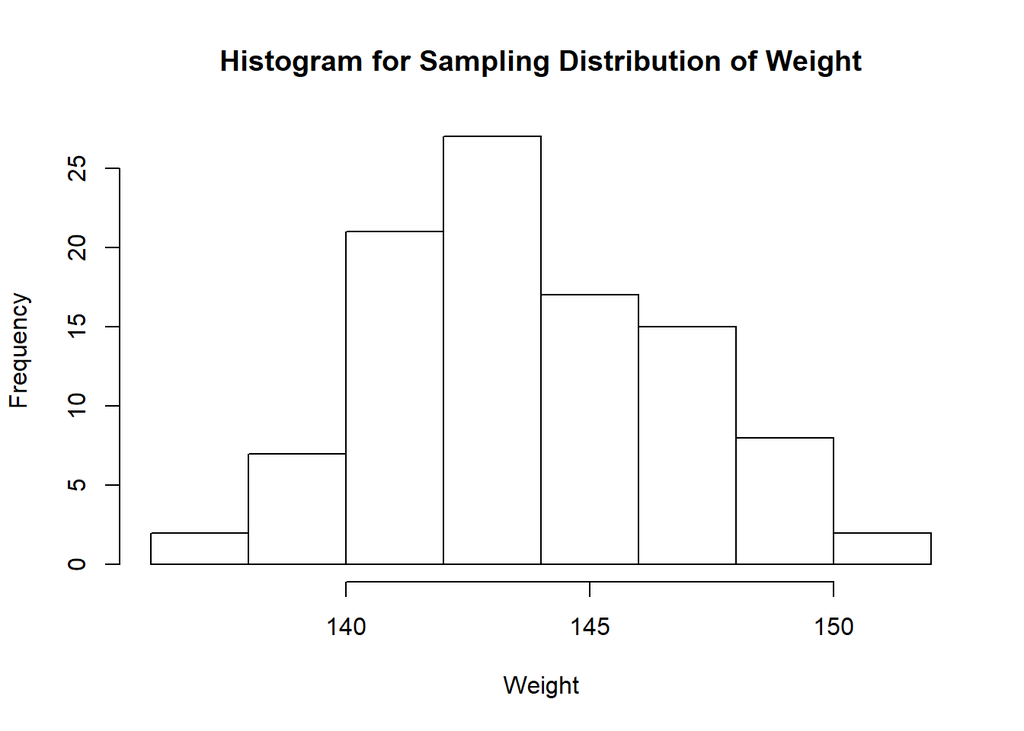

```r
hist(wsdm, main = "Histogram for Sampling Distribution of Weight", xlab = "Weight")
```

Seems like it is close to a normal distribution.

**Age:**

```r
a_sample_dis <- NULL
for (i in 1:99){
    a_sample_dis[[i]] <- sample(a,size=30, replace=FALSE)
}
head(a_sample_dis)
```

```
## [[1]]
##  [1] 19.22270 24.14823 19.87259 16.65884 19.89808 21.69196 22.40936
##  [8] 18.82258 21.66344 18.99324 18.31203 27.58828 20.24615 24.01948
## [15] 16.56274 14.07024 23.53162 26.52334 20.91836 18.23469 22.55533
## [22] 19.38432 17.49842 21.76792 20.89564 20.38294 21.10780 15.64708
## [29] 20.93505 23.88692
##
## [[2]]
##  [1] 15.94527 21.58286 16.84876 19.63260 21.54377 17.94266 16.19529
##  [8] 22.19918 19.18691 18.50000 27.55380 23.10560 23.89309 20.79042
## [15] 20.35920 17.88162 22.56667 21.06841 24.00246 17.36646 19.21670
## [22] 20.98622 20.00607 17.06348 18.52872 17.67434 19.71057 21.64507
## [29] 18.99324 23.19870
##
## [[3]]
```

[output cut: 26 more lines]

```r
asdm <- NULL
for (i in 1:99){
    asdm[i] <- mean(a_sample_dis[[i]])
}
mean(asdm)
```

```
## [1] 20.09464
```

```r
sd(asdm)
```

```
## [1] 0.5422549
```

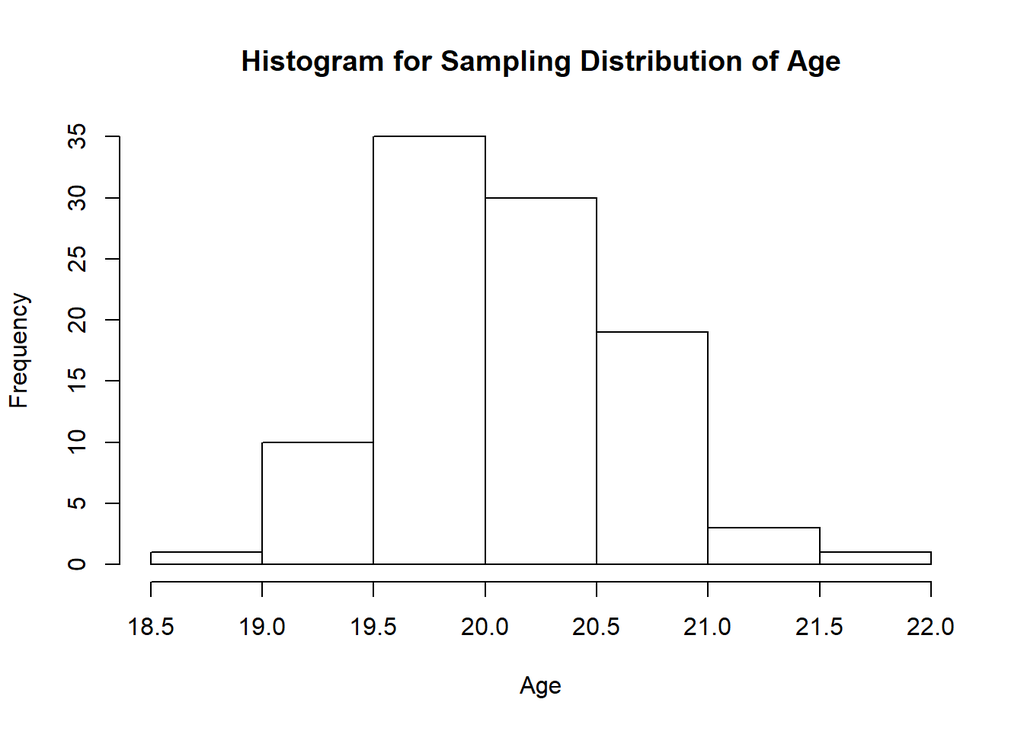

```r
hist(asdm, main = "Histogram for Sampling Distribution of Age", xlab = "Age")
```

Seems close to normal distribution. I wonder if this would be more clear if I were to play with the bin size for the x-axis? May try this for final code.

**Number of Zombies Killed:**

```r
k_sample_dis <- NULL
for (i in 1:99){
    k_sample_dis[[i]] <- sample(k,size=30, replace=FALSE)
}
head(k_sample_dis)
```

```
## [[1]]
##  [1] 2 3 3 1 1 2 3 2 3 0 3 3 0 0 2 1 4 1 5 5 4 5 4 6 2 5 3 3 6 2
##
## [[2]]
##  [1] 3 1 1 4 1 1 3 2 3 8 3 5 4 2 6 3 2 4 4 2 5 1 1 6 2 3 3 4 0 2
##
## [[3]]
##  [1] 2 0 3 3 6 3 4 4 3 2 5 5 2 3 3 1 3 0 3 3 3 1 3 2 2 2 4 4 1 5
##
## [[4]]
##  [1] 3 3 1 7 2 5 3 3 1 6 1 3 8 4 2 4 4 0 3 4 3 3 3 2 4 3 3 1 2 1
##
## [[5]]
##  [1] 2 1 6 3 3 1 1 2 2 2 3 1 1 2 4 1 2 3 5 7 2 3 2 6 5 2 1 1 2 3
##
## [[6]]
##  [1] 2 5 2 1 4 2 5 3 3 3 4 2 2 3 5 6 2 3 3 4 3 1 1 1 3 2 5 3 1 3
```

```r
ksdm <- NULL
for (i in 1:99){
    ksdm[i] <- mean(k_sample_dis[[i]])
}
mean(ksdm)
```

```
## [1] 2.958586
```

```r
sd(ksdm)
```

```
## [1] 0.2818425
```

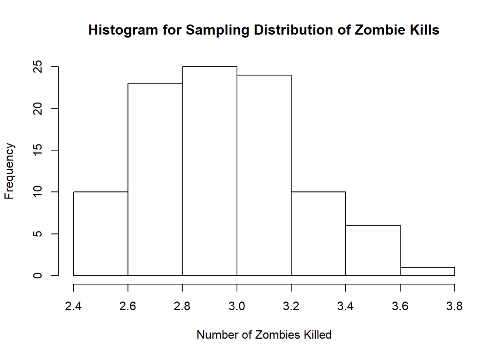

```r
hist(ksdm, main = "Histogram for Sampling Distribution of Zombie Kills", xlab = "Number of Zombies Killed")
```

This one still seems a bit right-skewed.

**Years of Education:**

```r
e_sample_dis <- NULL
for (i in 1:99){
    e_sample_dis[[i]] <- sample(e,size=30, replace=FALSE)
}
head(e_sample_dis)
```

```
## [[1]]
##  [1] 7 1 0 5 2 2 3 4 3 5 3 5 2 4 5 2 4 3 5 5 7 3 1 1 5 4 3 5 1 1
##
## [[2]]
##  [1] 1 3 2 2 5 2 4 1 6 2 2 2 1 4 3 1 5 2 6 2 2 4 2 5 0 3 3 2 4 1
##
## [[3]]
##  [1] 4 4 3 2 2 2 4 3 4 2 4 0 5 1 1 2 3 4 2 6 1 2 5 1 6 1 0 3 3 1
##
## [[4]]
##  [1] 0 2 7 5 0 1 4 2 5 3 1 3 3 1 0 3 2 3 4 2 3 1 2 2 2 3 1 3 3 4
##
## [[5]]
##  [1] 4 3 4 3 1 1 2 3 1 1 1 4 4 2 2 4 2 3 2 5 2 2 4 4 7 4 4 6 5 6
##
## [[6]]
##  [1] 2 1 3 7 5 3 3 2 1 3 2 2 2 5 2 2 2 3 0 3 5 1 4 2 2 2 3 3 3 1
```

```r
esdm <- NULL
for (i in 1:99){
    esdm[i] <- mean(e_sample_dis[[i]])
}
mean(esdm)
```

```
## [1] 3.054882
```

```r
sd(esdm)
```

```
## [1] 0.3059987
```

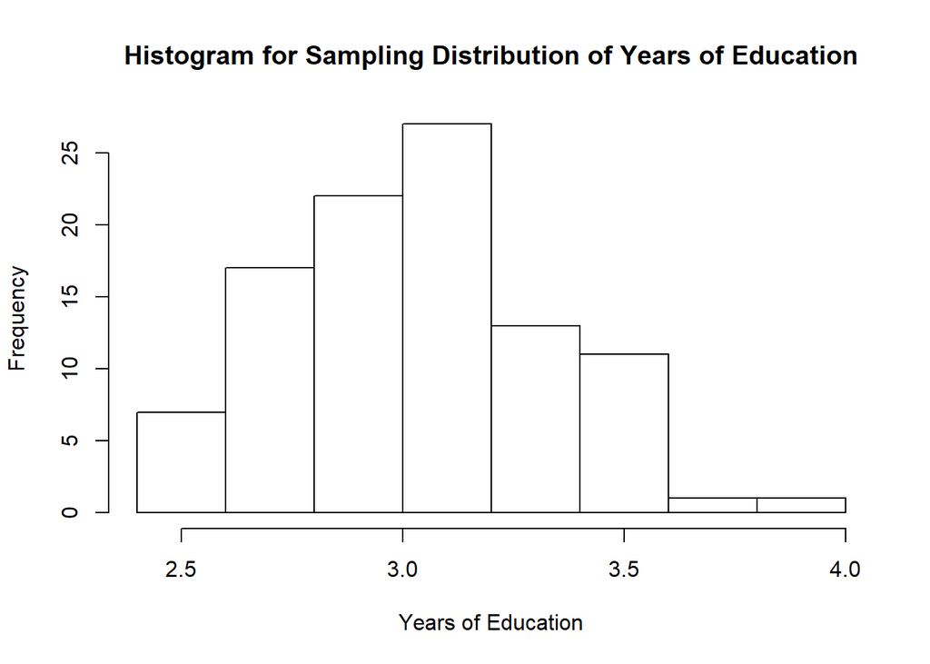

```r
hist(esdm, main = "Histogram for Sampling Distribution of Years of Education", xlab = "Years of Education")
```

This one looks like more of a normal distribution than the population distribution for this same variable. Still slightly right-skewed though?

## Challenges:

1. Curious if there is any easier way to find the population standard deviation? Perhaps a function in a package I do not know about?
2. Learning ggplot2 more! It seems like it can do so much, so I want to become more familiar with it.
3. Need to learn more about distribution types and how to tell them apart, as well as what that means for how we can or cannot maipulate and analyze data.
4. Not sure if I did the bootstrapping correctly for the confidence intervals for Number of Zombies Killed and Years of Education?
5. Not sure how to manipulate the bin size for the x-axis data on a histogram. This could be very useful to know!